# How many salamanders are in the forest?

SPARCNet group

Capture-mark-recapture methods are widely used to estimate population abundances of mobile animals in the wild. For this, a proportion of the population of interest is captured, marked, and released. During another sampling period, another proportion is captured and the number of marked individuals within the sample is counted. Assuming the number of marked individuals within the second sample is proportional to the number of marked individuals in the whole population, an estimate of the total population size (N) can be obtained by dividing the number of marked individuals by the proportion of marked individuals in the second sample.

Learning outcomes:

- Estimate population abundance using the Lincoln-Petersen index

Resources:

Datasets:

- [SPARCNet mark-recapture data](https://raisahernandez.github.io/General-Ecology/mark_recap.csv)

**Part I: Understanding the Lincoln-Petersen index**

The Lincoln-Peterson method is the simplest mark and recapture method. The procedure involves capturing a number of individuals, marking, releasing, and then recapturing to check for marked individuals. All of this needs to be done over a relatively short period of time. The second sample needs to be random and allow for the unmarked individuals to have the same opportunity to be captured.

**Lincoln-Petersen index**:

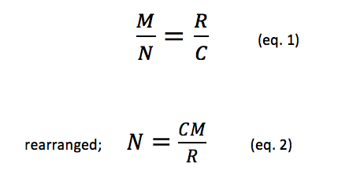

where;

*M* is the number of individuals marked in the first sample,

*C* is the total number of individuals captured in the second sample,

*R* is the number of marked individuals in the second sample

This formula considers that once an individual is counted it is not replaced back into the population, and thus, assumes individuals are not sampled twice. As long as *M* + *C* is greater than or equal to *N* and at least 7 recaptures were found this formula can be used.

**Other assumptions of the method are**:

- the population is closed (geographically and demographically)
- all individuals are equally likely to be captured
- marks don’t affect catchability nor survival
- marks are not lost
- samples are random

**Part II: Estimating the Lincoln-Petersen index**

Step 1: Exploring SPARCNet capture-mark-recapture data

Download SPARCNet capture-mark-recapture data to your working directory and import it to RStudio.

```r
# Previewing the data
View(mark_recap)

# Exploring the structure of the dataframe
str(mark_recap)

# Extracting the column "m" of the dataframe
mark_recap$m

# Extracting the column "c" of the dataframe
mark_recap$c

# Extracting the column "r" of the dataframe
mark_recap$r
```

> **Question 1:** How many observations and variables “mark_recap” has?

Step 2: Based on your understanding of the Lincoln-Petersen index, generate a hypothesis on the abundance of salamanders across sites.

> **Question 1:** Explain briefly what criteria did you use to build your hypothesis.

Step 3. Estimating the Lincoln-Petersen index  
To estimate the index for every season and site, create a new column in your dataframe named “n” using the dollar sign “$” and then fill in the column with the index’s formula.

```r
# Estimating abundance N using the Lincoln-Petersen index by creating a new column in the dataframe named "n". Then, write down the rearranged formula using the varibales in the dataframe as you learned in previous steps
mark_recap$n <- (mark_recap$m*mark_recap$c)/mark_recap$r

# Checking your new dataframe
mark_recap
```

> **Question 1:** Is your hypothesis supported by the evidence? Explain.

> **Question 2:** Can you make a claim based on the evidence provided. State your claim and provide evidence from the data to support your claim. Be sure to refer to specific parts of the dataframe.

> **Question 3:** What are the assumptions of the model, and how might your answer change if these assumptions were relaxed?

**Part III: Visualizing the data on salamander abundance**

A crucial part of research is result dissemination through good data visualization. Let’s plot the estimated population abundances across seasons and sites.

> **Question 1:** According to the type of variables you have (i.e., categorical, continuous), what is the most appropriate type of graph to present your data on abundance?

> **Question 2:** What descriptive statistics you should use in the viasualization?

Part I: Estimating average abundances

The package Rmisc allows you to estimate descriptive statistics easily using the command summarySE(). Go ahead, install and load this package in R.

```r
install.packages("Rmisc",repos='http://cran.us.r-project.org')
library(Rmisc)
```

To get a summary of descriptive statistics (mean, SD, SE, 95%CI) use the function summarySE(). The first argument in this function is the dataframe (mark_recap), and the subsequent arguments are the column name of the variable to be summarized (dependent variable) and the column name containing the grouping variable (independent variable).

```r
# Getting descriptive stats for abundance across sites
sum <- summarySE(mark_recap,"n","site")

# Checking the new object created
sum
```

> **Question 1:** What information does “sum” contains?

Step 2. Plotting average salamander abundance across sites

```r
# Barplot
barplot(sum$n)

# Adding the x-axis label
barplot(sum$n,names.arg = sum$site)

# Adding the y-axis lable
barplot(sum$n,names.arg = sum$site, ylab="Salamander abundance")
```

> **Challenge:** Estimate the average salamander abundance across seasons.

Your next steps as a scientist: what new question do you think should be investigated? What future data should be collected to answer your question?

**FIN**

**Great Work!**